# Implementing MLP's differrent architectures

## Implementing differrent MLP architectures

1. 2-Layer MLP architecture
2. 3-Layer MLP architecture
3. 5-Layer MLP architecture

All above architectures are implemented with Dropout and Batch-Normalization layer ini between

```python
import warnings
from sklearn.exceptions import DataConversionWarning
warnings.filterwarnings(action='ignore', category=DataConversionWarning)

# For plotting purposes
import matplotlib.pyplot as plt
import seaborn as sns
from sklearn.preprocessing import MinMaxScaler
from keras.utils import to_categorical
from keras.models import Sequential
from keras.initializers import he_normal
from keras.layers import BatchNormalization, Dense, Dropout
from keras.utils import np_utils
from keras.initializers import RandomNormal
# Import MNIST Dataset
from keras.datasets import mnist
```

### Loading the MNIST data and printing the input shape

```python
# the data, shuffled and split between train and test sets
(X_train, y_train), (X_test, y_test) = mnist.load_data()

print("Number of training examples :", X_train.shape[0], "and each image is of shape (%d, %d)"%(X_train.shape[1], X_train.shape[2]))
print("Number of training examples :", X_test.shape[0], "and each image is of shape (%d, %d)"%(X_test.shape[1], X_test.shape[2]))
```

```
Number of training examples : 60000 and each image is of shape (28, 28)
Number of training examples : 10000 and each image is of shape (28, 28)
```

### Transforming the input data into 1*784

```python
#Converting the input into a One dimensional vector (1*784)

X_train = X_train.reshape(X_train.shape[0], X_train.shape[1]*X_train.shape[2])
X_test = X_test.reshape(X_test.shape[0], X_test.shape[1]*X_test.shape[2])

#Printing the values of each image shape.
print("Number of training examples :", X_train.shape[0], "and each image is of shape (%d)"%(X_train.shape[1]))
print("Number of training examples :", X_test.shape[0], "and each image is of shape (%d)"%(X_test.shape[1]))

# An example data point
print(X_train[0])
```

```
Number of training examples : 60000 and each image is of shape (784)
Number of training examples : 10000 and each image is of shape (784)
[  0   0   0   0   0   0   0   0   0   0   0   0   0   0   0   0   0   0
   0   0   0   0   0   0   0   0   0   0   0   0   0   0   0   0   0   0
   0   0   0   0   0   0   0   0   0   0   0   0   0   0   0   0   0   0
   0   0   0   0   0   0   0   0   0   0   0   0   0   0   0   0   0   0
   0   0   0   0   0   0   0   0   0   0   0   0   0   0   0   0   0   0
   0   0   0   0   0   0   0   0   0   0   0   0   0   0   0   0   0   0
   0   0   0   0   0   0   0   0   0   0   0   0   0   0   0   0   0   0
   0   0   0   0   0   0   0   0   0   0   0   0   0   0   0   0   0   0
   0   0   0   0   0   0   0   0   3  18  18  18 126 136 175  26 166 255
 247 127   0   0   0   0   0   0   0   0   0   0   0   0  30  36  94 154
 170 253 253 253 253 253 225 172 253 242 195  64   0   0   0   0   0   0
   0   0   0   0   0  49 238 253 253 253 253 253 253 253 253 251  93  82
  82  56  39   0   0   0   0   0   0   0   0   0   0   0   0  18 219 253
```

[output cut: 31 more lines]

```python
#Normalizing the vector space using min-max normalization

X_train = X_train/255
X_test = X_test/255
```

```python
print("Class label of first image :", y_train[0])

# lets convert this into a 10 dimensional vector
# ex: consider an image is 5 convert it into 5 => [0, 0, 0, 0, 0, 1, 0, 0, 0, 0]
# this conversion needed for MLPs

Y_train = np_utils.to_categorical(y_train, 10)
Y_test = np_utils.to_categorical(y_test, 10)


# some model parameters

output_dim = 10
input_dim = X_train.shape[1]

batch_size = 128
nb_epoch = 20

# Plot train and cross validation loss
def plot_train_cv_loss(trained_model, epochs, colors=['b']):
    fig, ax = plt.subplots(1,1)
    ax.set_xlabel('epoch')
    ax.set_ylabel('Categorical Crossentropy Loss')
    x_axis_values = list(range(1,epochs+1))

    validation_loss = trained_model.history['val_loss']
    train_loss = trained_model.history['loss']

    ax.plot(x_axis_values, validation_loss, 'b', label="Validation Loss")
    ax.plot(x_axis_values, train_loss, 'r', label="Train Loss")
    plt.legend()
    plt.grid()
    fig.canvas.draw()


# Plot weight distribution using violin plot
def plot_weights(model):
    w_after = model.get_weights()

    o1_w = w_after[0].flatten().reshape(-1,1)
    o2_w = w_after[2].flatten().reshape(-1,1)
    out_w = w_after[4].flatten().reshape(-1,1)


    fig = plt.figure(figsize=(10,7))
    plt.title("Weight matrices after model trained\n")
    plt.subplot(1, 3, 1)
    plt.title("Trained model\n Weights")
    ax = sns.violinplot(y=o1_w,color='b')
    plt.xlabel('Hidden Layer 1')

    plt.subplot(1, 3, 2)
    plt.title("Trained model\n Weights")
    ax = sns.violinplot(y=o2_w, color='r')
    plt.xlabel('Hidden Layer 2 ')

    plt.subplot(1, 3, 3)
    plt.title("Trained model\n Weights")
    ax = sns.violinplot(y=out_w,color='y')
    plt.xlabel('Output Layer ')
    plt.show()
```

```
Class label of first image : 5
```

## Implementing 2-layer MLP architecture with relu as an activation function

```python
#2 Layer architecture using relu activation function

model_relu = Sequential()
model_relu.add(Dense(512, activation='relu', input_shape=(input_dim,), kernel_initializer=RandomNormal(mean=0.0, stddev=0.062, seed=None)))
model_relu.add(Dense(128, activation='relu', kernel_initializer=RandomNormal(mean=0.0, stddev=0.125, seed=None)) )
model_relu.add(Dense(output_dim, activation='softmax'))

print(model_relu.summary())

model_relu.compile(optimizer='adam', loss='categorical_crossentropy', metrics=['accuracy'])

history = model_relu.fit(X_train, Y_train, batch_size=batch_size, epochs=nb_epoch, verbose=1, validation_data=(X_test, Y_test))
```

```
_________________________________________________________________
Layer (type)                 Output Shape              Param #
=================================================================
dense_1 (Dense)              (None, 512)               401920
_________________________________________________________________
dense_2 (Dense)              (None, 128)               65664
_________________________________________________________________
dense_3 (Dense)              (None, 10)                1290
=================================================================
Total params: 468,874
Trainable params: 468,874
Non-trainable params: 0
_________________________________________________________________
None
Train on 60000 samples, validate on 10000 samples
```

```python
#Printing the score of the above model
score = model_relu.evaluate(X_test, Y_test, verbose=0)
print('Test score:', score[0])
print('Test accuracy:', score[1])
```

```
Test score: 0.0978071436640309
Test accuracy: 0.98
```

### Visualizing the performance of the model

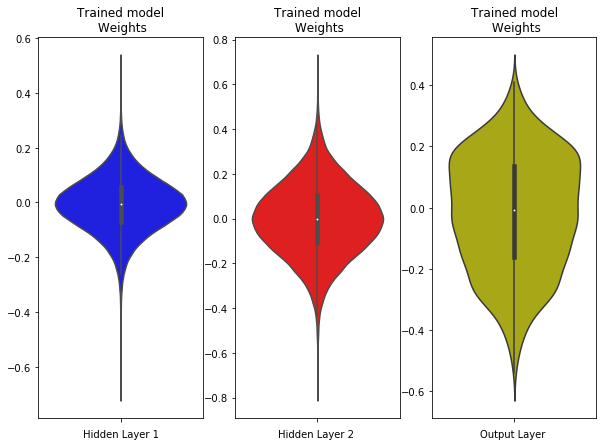

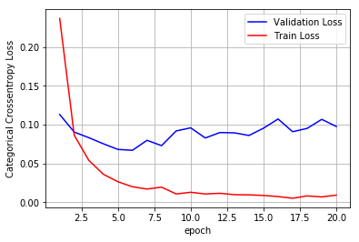

```python
# Plot weight distribution using violin plot
plot_weights(model_relu)

warnings.filterwarnings(action='ignore', category=DataConversionWarning)

print()
print()

# Plot train and cross validation error
plot_train_cv_loss(history, nb_epoch)
```

### Observations:-

- In the above diagram we can see that there is a huge gap between the Train-loss and the Validation loss in 20 epochs which is clear sign that the model is overfitting.
- The above 2-layer MLP model is a simple Neural-network in which no normalization and dropout layers are added.
- Lets see how the model behaves with the inclusion of batch-normalization.

### 2-layer MLP with Batch-normalization

```python
from keras.layers.normalization import BatchNormalization
from keras import initializers
model_batch = Sequential()

model_batch.add(Dense(512, activation='relu', input_shape=(input_dim,),  kernel_initializer=initializers.he_normal(seed=None)))
model_batch.add(BatchNormalization())

model_batch.add(Dense(128, activation='relu',kernel_initializer=initializers. he_normal(seed=None)) )
model_batch.add(BatchNormalization())

model_batch.add(Dense(output_dim, activation='softmax'))


model_batch.summary()
```

```
_________________________________________________________________
Layer (type)                 Output Shape              Param #
=================================================================
dense_4 (Dense)              (None, 512)               401920
_________________________________________________________________
batch_normalization_1 (Batch (None, 512)               2048
_________________________________________________________________
dense_5 (Dense)              (None, 128)               65664
_________________________________________________________________
batch_normalization_2 (Batch (None, 128)               512
_________________________________________________________________
dense_6 (Dense)              (None, 10)                1290
=================================================================
Total params: 471,434
Trainable params: 470,154
Non-trainable params: 1,280
_________________________________________________________________
```

### Compiling and fitting the above model

```python
model_batch.compile(optimizer='adam', loss='categorical_crossentropy', metrics=['accuracy'])

History = model_batch.fit(X_train, Y_train, batch_size=batch_size, epochs=nb_epoch, verbose=1, validation_data=(X_test, Y_test))
```

```
Train on 60000 samples, validate on 10000 samples
```

```python
score = model_batch.evaluate(X_test, Y_test, verbose=0)
print('Test score:', score[0])
print('Test accuracy:', score[1])
```

```
Test score: 0.07969029123196178
Test accuracy: 0.9808
```

### Visualizing the performance of the above model

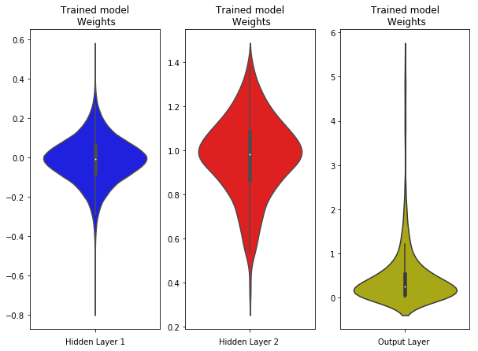

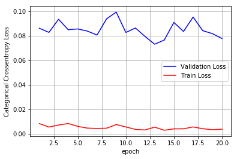

```python
# Plot weight distribution using violin plot
plot_weights(model_batch)

warnings.filterwarnings(action='ignore', category=DataConversionWarning)

print()
print()

# Plot train and cross validation error
plot_train_cv_loss(History, nb_epoch)
```

## Implementing the dropout layer into the above model

```python
from keras.layers import Dropout

model_drop = Sequential()

model_drop.add(Dense(512, activation='relu', input_shape=(input_dim,),  kernel_initializer=initializers.he_normal(seed=None)))
model_drop.add(BatchNormalization())
model_drop.add(Dropout(0.5))

model_drop.add(Dense(128, activation="relu",  kernel_initializer=initializers.he_normal(seed=None)) )
model_drop.add(BatchNormalization())
model_drop.add(Dropout(0.5))

model_drop.add(Dense(output_dim, activation='softmax'))


model_drop.summary()
```

```
_________________________________________________________________
Layer (type)                 Output Shape              Param #
=================================================================
dense_7 (Dense)              (None, 512)               401920
_________________________________________________________________
batch_normalization_3 (Batch (None, 512)               2048
_________________________________________________________________
dropout_1 (Dropout)          (None, 512)               0
_________________________________________________________________
dense_8 (Dense)              (None, 128)               65664
_________________________________________________________________
batch_normalization_4 (Batch (None, 128)               512
_________________________________________________________________
dropout_2 (Dropout)          (None, 128)               0
_________________________________________________________________
dense_9 (Dense)              (None, 10)                1290
=================================================================
Total params: 471,434
Trainable params: 470,154
Non-trainable params: 1,280
_________________________________________________________________
```

```python
model_drop.compile(optimizer='adam', loss='categorical_crossentropy', metrics=['accuracy'])

drop_his = model_drop.fit(X_train, Y_train, batch_size=batch_size, epochs=nb_epoch, verbose=1, validation_data=(X_test, Y_test))
```

```
Train on 60000 samples, validate on 10000 samples
```

```python
score = model_drop.evaluate(X_test, Y_test, verbose=0)
print('Test score:', score[0])
print('Test accuracy:', score[1])
```

```
Test score: 0.05715570239143854
Test accuracy: 0.9844
```

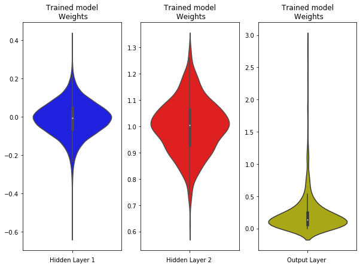

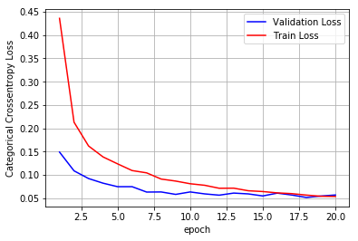

```python
# Plot weight distribution using violin plot
plot_weights(model_drop)

warnings.filterwarnings(action='ignore', category=DataConversionWarning)

print()
print()

# Plot train and cross validation error
plot_train_cv_loss(drop_his, nb_epoch)
```

### Observations:

- After studying the above plot we can see a clear improvement in the model as the gap between both the losses is very small which means the model is less overfiiting as compared to the previous models.
- The model starts performing well between the 13-20 epochs.
- The categorical cross-entropy loss is around 0.057 with 98.44 % accuracy.

## Implementing 3-layer MLP architecture with Batch-Normalization

```python
model_3l_batch = Sequential()

model_3l_batch.add(Dense(1024, activation='relu', input_shape=(input_dim,),  kernel_initializer=initializers.he_normal(seed=None)))
model_3l_batch.add(BatchNormalization())

model_3l_batch.add(Dense(512, activation='relu',kernel_initializer=initializers. he_normal(seed=None)) )
model_3l_batch.add(BatchNormalization())

model_3l_batch.add(Dense(128, activation='relu',kernel_initializer=initializers. he_normal(seed=None)) )
model_3l_batch.add(BatchNormalization())

model_3l_batch.add(Dense(output_dim, activation='softmax'))


model_3l_batch.summary()
```

```
_________________________________________________________________
Layer (type)                 Output Shape              Param #
=================================================================
dense_10 (Dense)             (None, 1024)              803840
_________________________________________________________________
batch_normalization_5 (Batch (None, 1024)              4096
_________________________________________________________________
dense_11 (Dense)             (None, 512)               524800
_________________________________________________________________
batch_normalization_6 (Batch (None, 512)               2048
_________________________________________________________________
dense_12 (Dense)             (None, 128)               65664
_________________________________________________________________
batch_normalization_7 (Batch (None, 128)               512
_________________________________________________________________
dense_13 (Dense)             (None, 10)                1290
=================================================================
Total params: 1,402,250
Trainable params: 1,398,922
Non-trainable params: 3,328
_________________________________________________________________
```

```python
model_3l_batch.compile(optimizer='adam', loss='categorical_crossentropy', metrics=['accuracy'])
final_model_batch =model_3l_batch.fit(X_train, Y_train, batch_size=batch_size, epochs=25, verbose=1, validation_data=(X_test, Y_test))
```

```
Train on 60000 samples, validate on 10000 samples
```

### Scores of the above 3-layer MLP model

```python
score_3l = model_3l_batch.evaluate(X_test, Y_test, verbose=0)
print('Test score:', score_3l[0])
print('Test accuracy:', score_3l[1])
```

```
Test score: 0.06487380075010915
Test accuracy: 0.984
```

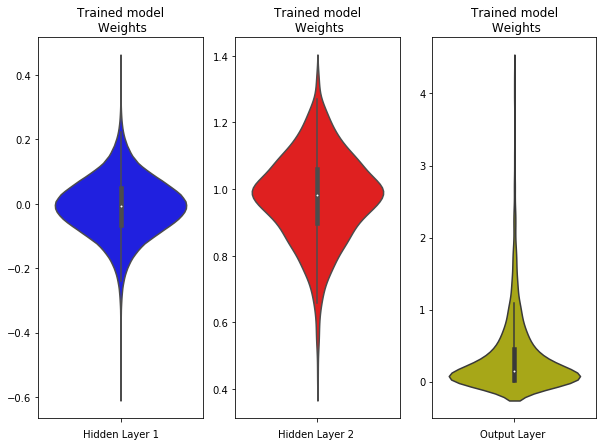

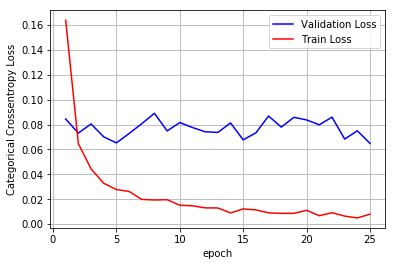

```python
# Plot weight distribution using violin plot
plot_weights(model_3l_batch)

epoch=25
# Plot train and cross validation error
plot_train_cv_loss(final_model_batch, epoch)
```

### Observation:

- In the above plot the 3-layer MLP model is clearly overfitting and need to be regularized with the help of drop-out layers.

## Implementing Drop-out layers into the 3-layer MLP model

```python
model_3l_drop = Sequential()
#First layer
model_3l_drop.add(Dense(1024, activation='relu', input_shape=(input_dim,),  kernel_initializer=initializers.he_normal(seed=None)))
model_3l_drop.add(BatchNormalization())
model_3l_drop.add(Dropout(0.3))

#Second Layer
model_3l_drop.add(Dense(512, activation="relu",  kernel_initializer=initializers.he_normal(seed=None)) )
model_3l_drop.add(BatchNormalization())
model_3l_drop.add(Dropout(0.3))

#Third Layer
model_3l_drop.add(Dense(128, activation="relu",  kernel_initializer=initializers.he_normal(seed=None)) )
model_3l_drop.add(BatchNormalization())
model_3l_drop.add(Dropout(0.3))

#Final Dense Layer
model_3l_drop.add(Dense(output_dim, activation='softmax'))


model_3l_drop.summary()
```

```
_________________________________________________________________
Layer (type)                 Output Shape              Param #
=================================================================
dense_14 (Dense)             (None, 1024)              803840
_________________________________________________________________
batch_normalization_8 (Batch (None, 1024)              4096
_________________________________________________________________
dropout_3 (Dropout)          (None, 1024)              0
_________________________________________________________________
dense_15 (Dense)             (None, 512)               524800
_________________________________________________________________
batch_normalization_9 (Batch (None, 512)               2048
_________________________________________________________________
dropout_4 (Dropout)          (None, 512)               0
_________________________________________________________________
dense_16 (Dense)             (None, 128)               65664
_________________________________________________________________
batch_normalization_10 (Batc (None, 128)               512
_________________________________________________________________
dropout_5 (Dropout)          (None, 128)               0
_________________________________________________________________
dense_17 (Dense)             (None, 10)                1290
=================================================================
Total params: 1,402,250
Trainable params: 1,398,922
Non-trainable params: 3,328
_________________________________________________________________
```

```python
model_3l_drop.compile(optimizer='adam', loss='categorical_crossentropy', metrics=['accuracy'])
final_model_drop =model_3l_drop.fit(X_train, Y_train, batch_size=batch_size, epochs=25, verbose=1, validation_data=(X_test, Y_test))
```

```
Train on 60000 samples, validate on 10000 samples
```

```python
score_3l_drop = model_3l_drop.evaluate(X_test, Y_test, verbose=0)
print('Test score:', score_3l_drop[0])
print('Test accuracy:', score_3l_drop[1])
```

```
Test score: 0.06286698746977418
Test accuracy: 0.9837
```

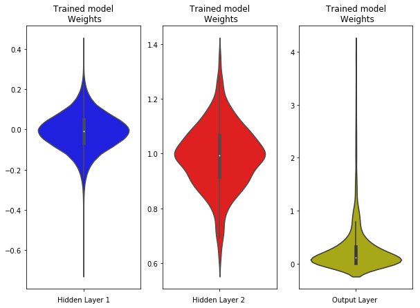

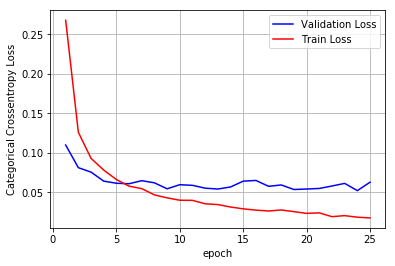

```python
# Plot weight distribution using violin plot
plot_weights(model_3l_drop)

epoch=25
# Plot train and cross validation error
plot_train_cv_loss(final_model_drop, epoch)
```

### Observations:

- After studying the above plot we can see a clear improvement in the model as the gap between both the losses is small which means the model is less overfiiting as compared to the previous models.
- The model ran for a total of 25 epochs.
- The categorical cross-entropy loss is around 0.062 with 98.37 % accuracy.

### Implementing the 5-Layer MLP model

```python
model_5l_drop = Sequential()

model_5l_drop.add(Dense(4096, activation='relu', input_shape=(input_dim,),  kernel_initializer=initializers.he_normal(seed=None)))
model_5l_drop.add(BatchNormalization())
model_5l_drop.add(Dropout(0.38))

model_5l_drop.add(Dense(2048, activation="relu",  kernel_initializer=initializers.he_normal(seed=None)) )
model_5l_drop.add(BatchNormalization())
model_5l_drop.add(Dropout(0.38))

model_5l_drop.add(Dense(1024, activation="relu",  kernel_initializer=initializers.he_normal(seed=None)) )
model_5l_drop.add(BatchNormalization())
model_5l_drop.add(Dropout(0.38))

model_5l_drop.add(Dense(512, activation='relu', input_shape=(input_dim,),  kernel_initializer=initializers.he_normal(seed=None)))
model_5l_drop.add(BatchNormalization())
model_5l_drop.add(Dropout(0.38))

model_5l_drop.add(Dense(128, activation='relu', input_shape=(input_dim,),  kernel_initializer=initializers.he_normal(seed=None)))
model_5l_drop.add(BatchNormalization())
model_5l_drop.add(Dropout(0.38))



model_5l_drop.add(Dense(output_dim, activation='softmax'))


model_5l_drop.summary()


Model_5l=model_5l_drop.compile(optimizer='adam', loss='categorical_crossentropy', metrics=['accuracy'])
final_5l_drop =model_5l_drop.fit(X_train, Y_train, batch_size=batch_size, epochs=25, verbose=1, validation_data=(X_test, Y_test))
```

```
_________________________________________________________________
Layer (type)                 Output Shape              Param #
=================================================================
dense_28 (Dense)             (None, 4096)              3215360
_________________________________________________________________
batch_normalization_18 (Batc (None, 4096)              16384
_________________________________________________________________
dropout_13 (Dropout)         (None, 4096)              0
_________________________________________________________________
dense_29 (Dense)             (None, 2048)              8390656
_________________________________________________________________
batch_normalization_19 (Batc (None, 2048)              8192
_________________________________________________________________
dropout_14 (Dropout)         (None, 2048)              0
_________________________________________________________________
dense_30 (Dense)             (None, 1024)              2098176
_________________________________________________________________
batch_normalization_20 (Batc (None, 1024)              4096
_________________________________________________________________
dropout_15 (Dropout)         (None, 1024)              0
_________________________________________________________________
dense_31 (Dense)             (None, 512)               524800
_________________________________________________________________
batch_normalization_21 (Batc (None, 512)               2048
_________________________________________________________________
dropout_16 (Dropout)         (None, 512)               0
_________________________________________________________________
dense_32 (Dense)             (None, 128)               65664
_________________________________________________________________
batch_normalization_22 (Batc (None, 128)               512
_________________________________________________________________
dropout_17 (Dropout)         (None, 128)               0
_________________________________________________________________
dense_33 (Dense)             (None, 10)                1290
=================================================================
Total params: 14,327,178
Trainable params: 14,311,562
Non-trainable params: 15,616
_________________________________________________________________
Train on 60000 samples, validate on 10000 samples
```

### Scores of the above model

```python
Model_5l_drop = model_5l_drop.evaluate(X_test, Y_test, verbose=0)
print('Test score:', Model_5l_drop[0])
print('Test accuracy:', Model_5l_drop[1])
```

```
Test score: 0.06666945320260712
Test accuracy: 0.9849
```

### Plotting the train and validation loss of the above model

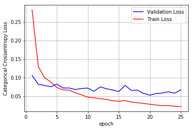

```python
epoch=25
# Plot train and cross validation error
plot_train_cv_loss(final_5l_drop,epoch)
```